# ORIE 4630 Final Project

Elizabeth Tang (et362), Manoli Lambrakis (el668), Will MacLeod (wm333)

2024-12-12

## 1)

The industry we chose to analyze was Consumers Cyclical - Auto Manufacturers. To represent this industry, we chose 3 companies, Tesla (TSLA), Toyota Motors (TM) and BYD (BYDDY) that had the highest market capitalizations of the listed auto manufacturers. We also chose to use the First Trust S-Network Future Vehicles & Technology ETF (CARZ) as a proxy for overall industry performance. CARZ is the only exchange traded fund that focuses on investing in auto manufacturers with around 101 equities represented. We thought this would be a close approximation since to be eligible for inclusion in the index, a company must be listed on a major recognized stock exchange and engaged in electric and autonomous vehicle manufacturing, enabling technologies or enabling materials.

```r
auto_manufacturers = c("TSLA", "TM", "BYDDY")

get_adj_prices <- function(symbol, start, end) {
  df = getSymbols(symbol, from = start, to = end, auto.assign = FALSE)
  col_name <- paste(symbol, ".Adjusted", sep="")
  return(df[,col_name])
}

# 2017-2019
tsla = get_adj_prices("TSLA", "2017-01-01", "2019-12-31")
head(tsla, 2)
```

```
##            TSLA.Adjusted
## 2017-01-03      14.46600
## 2017-01-04      15.13267
```

```r
tm = get_adj_prices("TM", "2017-01-01", "2019-12-31")
head(tm, 2)
```

```
##            TM.Adjusted
## 2017-01-03      118.55
## 2017-01-04      121.19
```

```r
byddy = get_adj_prices("BYDDY", "2017-01-01", "2019-12-31")
head(byddy, 2)
```

```
##            BYDDY.Adjusted
## 2017-01-03       10.33037
## 2017-01-04       10.49449
```

```r
auto = get_adj_prices("CARZ", "2017-01-01", "2019-12-31")
head(auto, 2)
```

```
##            CARZ.Adjusted
## 2017-01-03      30.12493
## 2017-01-04      30.83011
```

```r
tbill1mo = getSymbols("DGS1MO", from = "2017-01-01", to = "2019-12-31", src="FRED", auto.assign = FALSE)
tbill1mo = na.omit(tbill1mo[,"DGS1MO"])
head(tbill1mo, 2)
```

```
##            DGS1MO
## 2017-01-03   0.52
## 2017-01-04   0.49
```

```r
get_daily_return <- function(symbol, start, end) {
  df = getSymbols(symbol, from = start, to = end, auto.assign = FALSE)
  col_name <- paste(symbol, ".Adjusted", sep="")
  return(dailyReturn(df[,col_name]))
}

# 2017-2019
tsla_ret = dailyReturn(tsla)
tm_ret = dailyReturn(tm)
byddy_ret = dailyReturn(byddy)
auto_ret = dailyReturn(auto)

# 2020-2022
tbill1mo_2 = getSymbols("DGS1MO", from = "2020-01-01", to = "2022-12-31", src="FRED", auto.assign = FALSE)
tbill1mo_2 = na.omit(tbill1mo_2[,"DGS1MO"])
rf_2 = tbill1mo_2/(360 * 100)

sp500_2 = getSymbols("^GSPC", from = "2020-01-01", to = "2022-12-31", auto.assign = FALSE)
sp500_2 = sp500_2[,'GSPC.Adjusted']
sp500_ret_2 = dailyReturn(sp500_2)

tsla_ret_2 = get_daily_return("TSLA", "2020-01-01", "2022-12-31")
tm_ret_2 = get_daily_return("TM", "2020-01-01", "2022-12-31")
byddy_ret_2 = get_daily_return("BYDDY", "2020-01-01", "2022-12-31")
auto_ret_2 = get_daily_return("CARZ", "2020-01-01", "2022-12-31")

calc_cum_ret <- function(ret) {
  gross_ret = ret + 1
  return(cumprod(gross_ret) - 1)
}
```

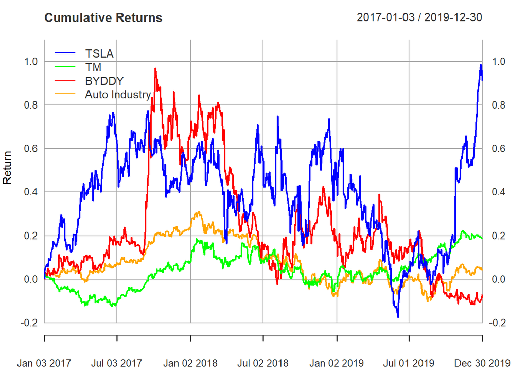

```r
combined_returns <- cbind(
  calc_cum_ret(tsla_ret),
  calc_cum_ret(tm_ret),
  calc_cum_ret(byddy_ret),
  calc_cum_ret(auto_ret)
)

p1 <- plot.xts(
  combined_returns,
  type = "l",
  col = c("blue", "green", "red", "orange"),
  main = "Cumulative Returns",
  ylab = "Return",
  xlab = "Days",
  ylim = c(-0.2, 1.1)
)

addLegend(
  "topleft",
  c("TSLA", "TM", "BYDDY", "Auto Industry"),
  col = c("blue", "green", "red", "orange"),
  lty = c(1,1,1,1)
)
```

## 2)

```r
symbols <- c("TSLA", "TM", "BYDDY", "CARZ")

periods <- list(
  c("2017-01-01", "2019-12-31"),
  c("2020-01-01", "2022-12-31")
)

get_stats <- function(symbols, periods) {
  mean_mat <- matrix(NA, nrow = length(symbols), ncol = length(periods))
  sd_mat <- matrix(NA, nrow = length(symbols), ncol = length(periods))

  for (i in seq_along(symbols)) {
    for (j in seq_along(periods)) {
      start_date <- periods[[j]][1]
      end_date <- periods[[j]][2]

      returns <- get_daily_return(symbols[i], start_date, end_date)

      mean_mat[i, j] <- mean(returns, na.rm = TRUE)
      sd_mat[i, j] <- sd(returns, na.rm = TRUE)
    }
  }
  return(list(mean_mat, sd_mat))
}

mean_mat = get_stats(symbols, periods)[1]
sd_mat = get_stats(symbols, periods)[2]

mean_df <- data.frame(mean_mat, row.names = c("TSLA", "TM", "BYDDY", "Auto Industry"))
colnames(mean_df) <- c("2017-2019", "2020-2022")

sd_df <- data.frame(sd_mat, row.names = c("TSLA", "TM", "BYDDY", "Auto Industry"))
colnames(sd_df) <- c("2017-2019", "2020-2022")

years <- list(
  c("2017-01-01", "2017-12-31"),
  c("2018-01-01", "2018-12-31"),
  c("2019-01-01", "2019-12-31")
)

mean_mat_years = get_stats(symbols, years)[[1]]
sd_mat_years = get_stats(symbols, years)[[2]]

mean_df_years <- data.frame(mean_mat_years, row.names = c("TSLA", "TM", "BYDDY", "Auto Industry"))
colnames(mean_df_years) <- c("2017", "2018", "2019")

sd_df_years <- data.frame(sd_mat_years, row.names = c("TSLA", "TM", "BYDDY", "Auto Industry"))
colnames(sd_df_years) <- c("2017", "2018", "2019")

# Round all output tables to 3 decimal places
mean_df <- round(mean_df, 3)
sd_df <- round(sd_df, 3)
mean_df_years <- round(mean_df_years, 3)
sd_df_years <- round(sd_df_years, 3)
```

## Split by period

### Mean of Daily Returns

```r
mean_df
```

```
##               2017-2019 2020-2022
## TSLA              0.001     0.003
## TM                0.000     0.000
## BYDDY             0.000     0.003
## Auto Industry     0.000     0.001
```

### Standard Deviation of Daily Returns

```r
sd_df
```

```
##               2017-2019 2020-2022
## TSLA              0.031     0.045
## TM                0.010     0.017
## BYDDY             0.023     0.040
## Auto Industry     0.010     0.022
```

## Split by year

### Mean of Daily Returns

```r
mean_df_years
```

```
##                2017   2018   2019
## TSLA          0.002  0.001  0.002
## TM            0.000  0.000  0.001
## BYDDY         0.002 -0.001 -0.001
## Auto Industry 0.001 -0.001  0.001
```

### Standard Deviation of Daily Returns

```r
sd_df_years
```

```
##                2017  2018  2019
## TSLA          0.022 0.037 0.031
## TM            0.008 0.012 0.009
## BYDDY         0.024 0.025 0.021
## Auto Industry 0.007 0.011 0.011
```

## 3)

```r
rf = tbill1mo/(360 * 100)

# mean excess returns
mu_rf.vec = c(mean(tsla_ret - rf), mean(tm_ret - rf), mean(byddy_ret - rf))
cov.mat = cov(cbind(tsla_ret, tm_ret, byddy_ret))
rownames(cov.mat) <- c("TSLA", "TM", "BYDDY")
colnames(cov.mat) <- c("TSLA", "TM", "BYDDY")

num = solve(cov.mat)%*%(mu_rf.vec)
den = as.numeric(t(rep(1,3))%*%solve(cov.mat)%*%(mu_rf.vec))
tan.vec = num/den

# mean excess return of tan pf
mu_tan_rf = as.numeric(crossprod(tan.vec, mu_rf.vec))
sd_tan = sqrt(as.numeric(t(tan.vec)%*%cov.mat%*%tan.vec))

# weights of each company in the optimal portfolio
tan.vec
```

```
##              [,1]
## TSLA   0.44867708
## TM     0.60061655
## BYDDY -0.04929364
```

```r
tsla_sr = mu_rf.vec[1]/sqrt(diag(cov.mat)[1])
tm_sr = mu_rf.vec[2]/sqrt(diag(cov.mat)[2])
byddy_sr = mu_rf.vec[3]/sqrt(diag(cov.mat)[3])
pf_sr = mu_tan_rf/sd_tan
auto_sr = mean(auto_ret - rf)/sd(auto_ret)

sharpe_ratios = data.frame(
  Portfolio = c("TSLA", "TM", "BYDDY", "Auto Industry", "Tan PF (opt)"),
  Sharpe_Ratio = c(tsla_sr, tm_sr, byddy_sr, auto_sr, pf_sr),
  SD = c(sqrt(diag(cov.mat)[1]), sqrt(diag(cov.mat)[2]), sqrt(diag(cov.mat)[3]), sd(auto_ret), sd_tan)
)

sharpe_ratios[,2:3] <- round(sharpe_ratios[,2:3], 3)
sharpe_ratios
```

```
##       Portfolio Sharpe_Ratio    SD
## 1          TSLA        0.045 0.031
## 2            TM        0.026 0.010
## 3         BYDDY        0.009 0.023
## 4 Auto Industry        0.009 0.010
## 5  Tan PF (opt)        0.049 0.016
```

As we can see in the statistics above, the riskiness (standard deviation) of the individual assets vary. TSLA has the highest SD (0.0306), making it the riskiest asset in the portfolio. BYDDY has a slightly lower SD (0.0233), making it less risky than TSLA, but still riskier than TM. TM actually had a SD similar to CARZ (0.0097 and 0.0098, respectively), indicating relatively low volatility in that individual asset. CARZ’s low volatility indicates that the industry as a whole is more stable, likely due to diversification across companies. Our optimal portfolio had a SD of 0.0157 which is slightly higher than the overall industry and TM, but much lower than TSLA and BYDDY. This indicates that our optimization process helped reduce risk through diversification.

TSLA had the highest SR (0.0455) among individual assets, offering high returns per unit risk, despite high risk. TM had a SR of 0.0255, which is lower than TSLA, but also lower risk overall. BYDDY had the lowest SR of all individual risks, making it less attractive individually, offering less return per unit risk despite having higher risks than TM. The overall auto industry (CARZ) had a SR of 0.0095 which is relatively low. Our optimal portfolio had the highest SR of 0.0486. This indicates that our portfolio takes advantage of diversification and produces high return for risk.

Individual investments like Tesla can provide high returns but must be combined with less volatile assets like Toyota or BYD to achieve an efficient portfolio. Tesla’s high Sharpe ratio suggests that it can add value to the portfolio despite its high risk, but relying solely on Tesla would expose the portfolio to excessive volatility. Toyota and BYD are lower-risk assets, but their Sharpe ratios make them less compelling individually. They may still contribute to portfolio stability. By considering these factors, an optimized portfolio, like ours, can greatly outperform the overall auto industry.

## 4)

### 2017-2019

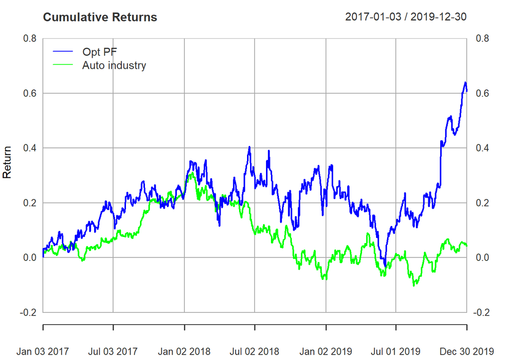

```r
pf_ret = (tan.vec[1] * tsla_ret + tan.vec[2] * tm_ret + tan.vec[3] * byddy_ret)
combined_returns <- cbind(
  calc_cum_ret(pf_ret),
  calc_cum_ret(auto_ret)
)

p2 <- plot.xts(
  combined_returns,
  type = "l",
  col = c("blue", "green"),
  main = "Cumulative Returns",
  ylab = "Return",
  xlab = "Days",
  ylim = c(-0.2, 0.8)
)

addLegend(
  "topleft",
  c("Opt PF", "Auto industry"),
  col = c("blue", "green"),
  lty = c(1,1,1,1)
)
```

```r
sprintf("SD of Opt PF Daily Return: %s", signif(sd(pf_ret), 3))
sprintf("SD of Auto Industry Daily Return: %s", signif(sd(auto_ret), 3))
sprintf("SR of Opt PF Daily Return: %s", signif(mean(pf_ret - rf)/sd(pf_ret), 3))
sprintf("SR of Auto Industry Daily Return: %s", signif(mean(auto_ret - rf)/sd(auto_ret), 3))
```

```
## [1] "SD of Opt PF Daily Return: 0.0157"
## [1] "SD of Auto Industry Daily Return: 0.00975"
## [1] "SR of Opt PF Daily Return: 0.0486"
## [1] "SR of Auto Industry Daily Return: 0.00948"
```

We can see that our optimized portfolio had higher cumulative returns than the overall auto industry for most of the period. Though our portfolio does have a higher SD (0.0157 vs 0.0098), we can also achieve a significantly higher Sharpe Ratio – almost 5x higher. Overall, our portfolio achieves higher returns for slightly more risk when compared to the overarching auto manufacturers industry in this period.

### 2020-2022

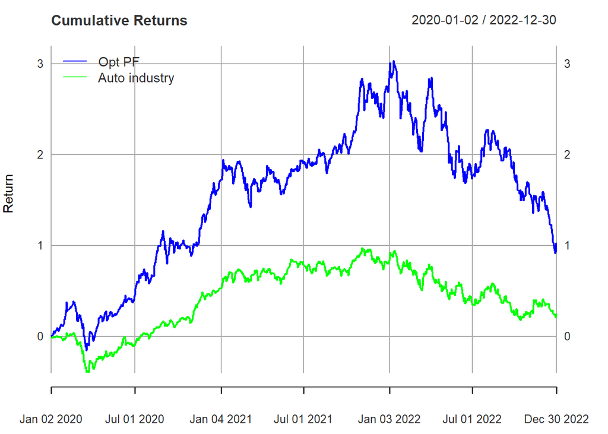

```r
pf_ret_2 = (tan.vec[1] * tsla_ret_2 + tan.vec[2] * tm_ret_2 + tan.vec[3] * byddy_ret_2)
combined_returns <- cbind(
  calc_cum_ret(pf_ret_2),
  calc_cum_ret(auto_ret_2)
)

p3 <- plot.xts(
  combined_returns,
  type = "l",
  col = c("blue", "green"),
  main = "Cumulative Returns",
  ylab = "Return",
  xlab = "Days",
  ylim = c(-0.4, 3.2)
)

addLegend(
  "topleft",
  c("Opt PF", "Auto industry"),
  col = c("blue", "green"),
  lty = c(1,1,1,1)
)
```

```r
sprintf("SD of Opt PF Daily Return: %s", signif(sd(pf_ret_2), 3))
sprintf("SD of Auto Industry Daily Return: %s", signif(sd(auto_ret_2), 3))
sprintf("SR of Opt PF Daily Return: %s", signif(mean(pf_ret_2 - rf_2)/sd(pf_ret_2), 3))
sprintf("SR of Auto Industry Daily Return: %s", signif(mean(auto_ret_2 - rf_2)/sd(auto_ret_2), 3))
```

```
## [1] "SD of Opt PF Daily Return: 0.0245"
## [1] "SD of Auto Industry Daily Return: 0.0217"
## [1] "SR of Opt PF Daily Return: 0.0467"
## [1] "SR of Auto Industry Daily Return: 0.0199"
```

In this period, our optimized portfolio had higher cumulative returns than the overall auto industry for the entire period. In this period, our portfolio had a similar SD as the overall industry (0.0245 vs 0.0217) but our Sharpe Ratio was more than 2x higher (0.0467 vs 0.0199). Overall, our portfolio again achieves significantly higher returns for slightly more risk when compared to the overarching auto manufacturers industry in this period. Compared to the last period, both our portfolio and the overall industry had much higher cumulative returns but also greater risk and volatility.

## 5)

```r
sp500 = getSymbols("^GSPC", from = "2017-01-01", to = "2019-12-31", auto.assign = FALSE)
sp500 = sp500[,'GSPC.Adjusted']
sp500_ret = dailyReturn(sp500)

tsla_ex = tsla_ret - rf
tm_ex = tm_ret - rf
byddy_ex = byddy_ret - rf
auto_ex = auto_ret - rf
pf_ex = (tan.vec[1] * tsla_ex + tan.vec[2] * tm_ex + tan.vec[3] * byddy_ex)
spy_ex = sp500_ret - rf

tsla_fit <- lm(tsla_ex ~ spy_ex)
tm_fit <- lm(tm_ex ~ spy_ex)
byddy_fit <- lm(byddy_ex ~ spy_ex)
auto_fit <- lm(auto_ex ~ spy_ex)
pf_fit <- lm(pf_ex ~ spy_ex)

summary(tsla_fit)
```

```
##
## Call:
## lm(formula = tsla_ex ~ spy_ex)
##
## Residuals:
##       Min        1Q    Median        3Q       Max
## -0.148097 -0.015056 -0.000588  0.013969  0.173406
##
## Coefficients:
##              Estimate Std. Error t value Pr(>|t|)
## (Intercept) 0.0007273  0.0010480   0.694    0.488
## spy_ex      1.3412053  0.1299194  10.323   <2e-16 ***
## ---
## Signif. codes:  0 '***' 0.001 '**' 0.01 '*' 0.05 '.' 0.1 ' ' 1
##
## Residual standard error: 0.02861 on 746 degrees of freedom
## Multiple R-squared:  0.125,  Adjusted R-squared:  0.1238
## F-statistic: 106.6 on 1 and 746 DF,  p-value: < 2.2e-16
```

```r
summary(tm_fit)
```

```
##
## Call:
## lm(formula = tm_ex ~ spy_ex)
##
## Residuals:
##       Min        1Q    Median        3Q       Max
## -0.028519 -0.004608  0.000004  0.004931  0.039885
##
## Coefficients:
##               Estimate Std. Error t value Pr(>|t|)
## (Intercept) -9.395e-05  2.926e-04  -0.321    0.748
## spy_ex       6.861e-01  3.627e-02  18.916   <2e-16 ***
## ---
## Signif. codes:  0 '***' 0.001 '**' 0.01 '*' 0.05 '.' 0.1 ' ' 1
##
## Residual standard error: 0.007987 on 746 degrees of freedom
## Multiple R-squared:  0.3242, Adjusted R-squared:  0.3233
## F-statistic: 357.8 on 1 and 746 DF,  p-value: < 2.2e-16
```

```r
summary(byddy_fit)
```

```
##
## Call:
## lm(formula = byddy_ex ~ spy_ex)
##
## Residuals:
##       Min        1Q    Median        3Q       Max
## -0.073363 -0.011815 -0.001419  0.010144  0.128607
##
## Coefficients:
##               Estimate Std. Error t value Pr(>|t|)
## (Intercept) -0.0002882  0.0008066  -0.357    0.721
## spy_ex       0.9843865  0.0999909   9.845   <2e-16 ***
## ---
## Signif. codes:  0 '***' 0.001 '**' 0.01 '*' 0.05 '.' 0.1 ' ' 1
##
## Residual standard error: 0.02202 on 746 degrees of freedom
## Multiple R-squared:  0.115,  Adjusted R-squared:  0.1138
## F-statistic: 96.92 on 1 and 746 DF,  p-value: < 2.2e-16
```

```r
summary(auto_fit)
```

```
##
## Call:
## lm(formula = auto_ex ~ spy_ex)
##
## Residuals:
##       Min        1Q    Median        3Q       Max
## -0.033061 -0.004695  0.000339  0.004920  0.029962
##
## Coefficients:
##               Estimate Std. Error t value Pr(>|t|)
## (Intercept) -0.0002989  0.0002724  -1.097    0.273
## spy_ex       0.7869974  0.0337714  23.304   <2e-16 ***
## ---
## Signif. codes:  0 '***' 0.001 '**' 0.01 '*' 0.05 '.' 0.1 ' ' 1
##
## Residual standard error: 0.007437 on 746 degrees of freedom
## Multiple R-squared:  0.4213, Adjusted R-squared:  0.4205
## F-statistic: 543.1 on 1 and 746 DF,  p-value: < 2.2e-16
```

```r
summary(pf_fit)
```

```
##
## Call:
## lm(formula = pf_ex ~ spy_ex)
##
## Residuals:
##       Min        1Q    Median        3Q       Max
## -0.069762 -0.007271 -0.000129  0.006302  0.080819
##
## Coefficients:
##              Estimate Std. Error t value Pr(>|t|)
## (Intercept) 0.0002841  0.0004987    0.57    0.569
## spy_ex      0.9653245  0.0618243   15.61   <2e-16 ***
## ---
## Signif. codes:  0 '***' 0.001 '**' 0.01 '*' 0.05 '.' 0.1 ' ' 1
##
## Residual standard error: 0.01361 on 746 degrees of freedom
## Multiple R-squared:  0.2463, Adjusted R-squared:  0.2453
## F-statistic: 243.8 on 1 and 746 DF,  p-value: < 2.2e-16
```

```r
alpha_beta = data.frame(
  Portfolio = c("TSLA", "TM", "BYDDY", "Auto Industry", "Tan PF (opt)"),
  alpha_values = c(tsla_fit$coefficients[1], tm_fit$coefficients[1], byddy_fit$coefficients[1], auto_fit$coefficients[1], pf_fit$coefficients[1]),
  beta_values = c(tsla_fit$coefficients[2], tm_fit$coefficients[2], byddy_fit$coefficients[2], auto_fit$coefficients[2], pf_fit$coefficients[2])
)

alpha_beta[,2:3] <- round(alpha_beta[,2:3], 3)
alpha_beta
```

```
##       Portfolio alpha_values beta_values
## 1          TSLA        0.001       1.341
## 2            TM        0.000       0.686
## 3         BYDDY        0.000       0.984
## 4 Auto Industry        0.000       0.787
## 5  Tan PF (opt)        0.000       0.965
```

All of the alphas were very close to 0 and we were unable to reject the null hypothesis (CAPM) for any of the assets/portfolios. Tesla exhibited higher market sensitivity (beta = 1.341). Toyota’s lower beta (0.686) highlights its stability, while BYD’s beta near 1 indicates higher correlation with the market. The overall industry had a relatively low beta (0.787), showing relative stability as well. The constructed portfolio managed to achieve relatively moderate risk (beta close to 1).

## 6)

```r
tsla_ex_2 = tsla_ret_2 - rf_2
tm_ex_2 = tm_ret_2 - rf_2
byddy_ex_2 = byddy_ret_2 - rf_2
auto_ex_2 = auto_ret_2 - rf_2
pf_ex_2 = (tan.vec[1] * tsla_ex_2 + tan.vec[2] * tm_ex_2 + tan.vec[3] * byddy_ex_2)
spy_ex_2 = sp500_ret_2 - rf_2

tsla_fit_2 <- lm(tsla_ex_2 ~ spy_ex_2)
tm_fit_2 <- lm(tm_ex_2 ~ spy_ex_2)
byddy_fit_2 <- lm(byddy_ex_2 ~ spy_ex_2)
auto_fit_2 <- lm(auto_ex_2 ~ spy_ex_2)
pf_fit_2 <- lm(pf_ex_2 ~ spy_ex_2)

summary(tsla_fit_2)
```

```
##
## Call:
## lm(formula = tsla_ex_2 ~ spy_ex_2)
##
## Residuals:
##       Min        1Q    Median        3Q       Max
## -0.190539 -0.021849 -0.001014  0.019868  0.185981
##
## Coefficients:
##             Estimate Std. Error t value Pr(>|t|)
## (Intercept) 0.002434   0.001431   1.701   0.0894 .
## spy_ex_2    1.454737   0.089080  16.331   <2e-16 ***
## ---
## Signif. codes:  0 '***' 0.001 '**' 0.01 '*' 0.05 '.' 0.1 ' ' 1
##
## Residual standard error: 0.03919 on 748 degrees of freedom
## Multiple R-squared:  0.2628, Adjusted R-squared:  0.2618
## F-statistic: 266.7 on 1 and 748 DF,  p-value: < 2.2e-16
```

```r
summary(tm_fit_2)
```

```
##
## Call:
## lm(formula = tm_ex_2 ~ spy_ex_2)
##
## Residuals:
##       Min        1Q    Median        3Q       Max
## -0.045294 -0.006785 -0.000231  0.006674  0.069875
##
## Coefficients:
##               Estimate Std. Error t value Pr(>|t|)
## (Intercept) -0.0002117  0.0004642  -0.456    0.649
## spy_ex_2     0.6628551  0.0288951  22.940   <2e-16 ***
## ---
## Signif. codes:  0 '***' 0.001 '**' 0.01 '*' 0.05 '.' 0.1 ' ' 1
##
## Residual standard error: 0.01271 on 748 degrees of freedom
## Multiple R-squared:  0.413,  Adjusted R-squared:  0.4122
## F-statistic: 526.2 on 1 and 748 DF,  p-value: < 2.2e-16
```

```r
summary(byddy_fit_2)
```

```
##
## Call:
## lm(formula = byddy_ex_2 ~ spy_ex_2)
##
## Residuals:
##       Min        1Q    Median        3Q       Max
## -0.107168 -0.022711 -0.003682  0.019885  0.199544
##
## Coefficients:
##             Estimate Std. Error t value Pr(>|t|)
## (Intercept) 0.002554   0.001349   1.893   0.0587 .
## spy_ex_2    1.002193   0.083986  11.933   <2e-16 ***
## ---
## Signif. codes:  0 '***' 0.001 '**' 0.01 '*' 0.05 '.' 0.1 ' ' 1
##
## Residual standard error: 0.03695 on 748 degrees of freedom
## Multiple R-squared:  0.1599, Adjusted R-squared:  0.1588
## F-statistic: 142.4 on 1 and 748 DF,  p-value: < 2.2e-16
```

```r
summary(auto_fit_2)
```

```
##
## Call:
## lm(formula = auto_ex_2 ~ spy_ex_2)
##
## Residuals:
##       Min        1Q    Median        3Q       Max
## -0.075015 -0.007446 -0.000328  0.007528  0.045002
##
## Coefficients:
##              Estimate Std. Error t value Pr(>|t|)
## (Intercept) 0.0001007  0.0004683   0.215     0.83
## spy_ex_2    1.0912756  0.0291492  37.438   <2e-16 ***
## ---
## Signif. codes:  0 '***' 0.001 '**' 0.01 '*' 0.05 '.' 0.1 ' ' 1
##
## Residual standard error: 0.01282 on 748 degrees of freedom
## Multiple R-squared:  0.652,  Adjusted R-squared:  0.6516
## F-statistic:  1402 on 1 and 748 DF,  p-value: < 2.2e-16
```

```r
summary(pf_fit_2)
```

```
##
## Call:
## lm(formula = pf_ex_2 ~ spy_ex_2)
##
## Residuals:
##       Min        1Q    Median        3Q       Max
## -0.087614 -0.009950 -0.000498  0.008958  0.088018
##
## Coefficients:
##              Estimate Std. Error t value Pr(>|t|)
## (Intercept) 0.0008390  0.0006791   1.235    0.217
## spy_ex_2    1.0014271  0.0422669  23.693   <2e-16 ***
## ---
## Signif. codes:  0 '***' 0.001 '**' 0.01 '*' 0.05 '.' 0.1 ' ' 1
##
## Residual standard error: 0.01859 on 748 degrees of freedom
## Multiple R-squared:  0.4287, Adjusted R-squared:  0.428
## F-statistic: 561.4 on 1 and 748 DF,  p-value: < 2.2e-16
```

```r
alpha_beta_2 = data.frame(
  Portfolio = c("TSLA", "TM", "BYDDY", "Auto Industry", "Tan PF (opt)"),
  alpha_values = c(coef(tsla_fit_2)["(Intercept)"], coef(tm_fit_2)["(Intercept)"], coef(byddy_fit_2)["(Intercept)"], coef(auto_fit_2)["(Intercept)"], coef(pf_fit_2)["(Intercept)"]),
  beta_values = c(tsla_fit_2$coefficients[2], tm_fit_2$coefficients[2], byddy_fit_2$coefficients[2], auto_fit_2$coefficients[2], pf_fit_2$coefficients[2])
)

alpha_beta_2[,2:3] <- round(alpha_beta_2[,2:3], 3)
alpha_beta_2
```

```
##       Portfolio alpha_values beta_values
## 1          TSLA        0.002       1.455
## 2            TM        0.000       0.663
## 3         BYDDY        0.003       1.002
## 4 Auto Industry        0.000       1.091
## 5  Tan PF (opt)        0.001       1.001
```

A lot of the alphas were very close to 0 and we were unable to reject the null hypothesis (CAPM) for many assets/portfolios. In this period, Tesla and BYDDY, however, had a slightly positive alpha, significant at a 9% significance level. This aligns with the high growth profile of both companies; both companies experienced a lot of public interest during the period. Tesla exhibited higher market sensitivity (beta = 1.455). Toyota’s lower beta (0.663) highlights its stability, while BYD’s beta near 1 indicates higher correlation with the market. In this period, the Auto Industry’s beta was close to 1, largely tracking the market. This indicates a lessening of the stability the industry saw in the previous period. The constructed portfolio managed to achieve relatively moderate risk again (beta close to 1).

## 7)

```r
S = 1000
#VaR confidence level =1-alpha
calc_np <- function(alpha, ret) {
  VaR_NP = -S*as.numeric(quantile(ret,alpha))
  L = -S*ret
  ES_NP = mean(L[L>VaR_NP])
  NP = c(VaR_NP, ES_NP)
  names(NP) = c("VaR", "ES")
  return(NP)
}

tsla_np = calc_np(0.05, tsla_ret)
tm_np = calc_np(0.05, tm_ret)
byddy_np = calc_np(0.05, byddy_ret)
auto_np = calc_np(0.05, auto_ret)

results_df <- data.frame(rbind(tsla_np, tm_np, byddy_np, auto_np))

rownames(results_df) <- c("TSLA", "TM", "BYDDY", "Auto Industry")

results_df <- round(results_df, 3)
results_df
```

```
##                  VaR     ES
## TSLA          43.141 68.172
## TM            16.261 21.345
## BYDDY         36.196 46.617
## Auto Industry 16.396 22.251
```

TSLA had the highest VaR (43.14) and ES (68.17), TM had the lowest among the individual assets with VaR (16.26) and ES (21.34) and BYD between them with VaR (36.2) and ES (46.62). The VaR and ES for the overall auto industry is very close to Toyota, reflecting a mix of more stable companies like Toyota and higher-risk companies, like Tesla with diversification effects.

## 8)

```r
tsla_np_2 = calc_np(0.05, tsla_ret_2)
tm_np_2 = calc_np(0.05, tm_ret_2)
byddy_np_2 = calc_np(0.05, byddy_ret_2)
auto_np_2 = calc_np(0.05, auto_ret_2)

results_df_2 <- data.frame(rbind(tsla_np_2, tm_np_2, byddy_np_2, auto_np_2))

colnames(results_df_2) <- c("VaR", "ES")
rownames(results_df_2) <- c("TSLA", "TM", "BYDDY", "Auto Industry")

results_df_2 <- round(results_df_2, 3)
results_df_2
```

```
##                  VaR     ES
## TSLA          68.035 98.761
## TM            25.876 37.028
## BYDDY         59.752 78.812
## Auto Industry 31.771 48.977
```

Both VaR and ES values increased significantly for all companies and the auto industry between 2017–2019 and 2020–2022. This suggests higher risk exposure and larger potential losses in extreme scenarios during 2020–2022 compared to 2017–2019. The relative ordering of risk among individual assets stayed the same between periods. The auto industry aggregate become significantly riskier, reflecting the combination of volatile growth companies like Tesla and BYD and more stable companies like Toyota.

## 9)

Our analysis of the auto manufacturers sector from 2017-2019 and 2020-2022 shows that careful portfolio construction can improve returns and manage risk better than simply holding the industry ETF (CARZ).

Before the pandemic (2017-2019), our optimized portfolio delivered better returns per unit of risk than the broad industry. During the pandemic period (2020-2022), despite higher overall volatility, the portfolio again outperformed the industry. This suggests that thoughtful selection of companies, rather than broad exposure, can result in a more efficient risk-return tradeoff, even in unstable times.

Comparing the two periods, Tesla had the highest market sensitivity (beta), while Toyota maintained a relatively low beta, offering stability. BYD had a beta near 1, aligning closely with market movements. Over time, the industry’s beta moved closer to 1, indicating that during the pandemic, company performance was more in line with overall market trends.

Tail risk increased significantly from 2017-2019 to 2020-2022. This was likely due to the pandemic’s impact, including supply chain problems, changing consumer behavior, and broader economic uncertainties. Tesla and BYD, as higher-growth firms, saw greater increases in VaR and ES, highlighting their vulnerability to market shocks. Even stable companies like Toyota experienced more downside risk.

The pandemic years were marked by unprecedented uncertainty, affecting all automakers. While some legacy companies like Toyota remained relatively stable, growth-focused companies like Tesla and BYD faced bigger swings. Overall, our findings emphasize the value of a carefully chosen portfolio, an understanding of market sensitivity, and close attention to risk measures. As the auto industry continues to evolve, investors should remain watchful, balancing potential high returns with the risks of an ever-changing market environment.